# Cell cycle sorting - differential LADs - K562

Tom van Schaik

2019-08-14

### Introduction

Differential LADs between G1 and G2 sorted cells, with 20kb normalized (& scaled) bins.

### Method

Using the modified voom trick to shrink variation and limma for the analysis.

### Set-up

Set the parameters and list the data.

```r
# Load dependencies
suppressMessages(suppressWarnings(library(GenomicRanges)))
suppressMessages(suppressWarnings(library(rtracklayer)))
suppressMessages(suppressWarnings(library(ggplot2)))
suppressMessages(suppressWarnings(library(reshape2)))
suppressMessages(suppressWarnings(library(ggbeeswarm)))
suppressMessages(suppressWarnings(library(limma)))
suppressMessages(suppressWarnings(library(edgeR)))
suppressMessages(suppressWarnings(library(RColorBrewer)))

cell <- "K562"


#
# Prepare output
output_dir <- paste0("ts190708_differential_analysis_BinsandLADs_", cell)
dir.create(output_dir, showWarnings = FALSE)

# Parameter to extend bins to a certain distance (bases) for a more accurate
# lamina interaction score
ext <- 0

# Get the samples data frame prepared
input_dir <- "results/counts/bin-20kb/"
hmm_dir <- "results/HMM/bin-20kb/"
samples <- grep("bulk",
                grep(cell, dir(input_dir), value = T),
                value = T, invert = T)
samples.lmnb2 <- grep("LMNB2", samples, value = T)

samples.count <- length(samples.lmnb2)

# Also put this into a data frame
samples.df <- data.frame(sample = samples.lmnb2,
                         name = gsub("_LMNB2.*", "",
                                     gsub("pADamID-", "", samples.lmnb2)),
                         cell = cell,
                         stringsAsFactors = FALSE)

# Finally, I want to manually set the factor levels for (in my opinion) the
# best order.
samples.df$cell <- factor(samples.df$cell, levels = unique(samples.df$cell))

samples.df$phase <- sapply(samples.df$name, function(x) strsplit(x, "_")[[1]][2])
samples.df$phase <- factor(samples.df$phase, levels = c("G1", "S", "G2"))

samples.df$replicate <- sapply(samples.df$name, function(x) strsplit(x, "_")[[1]][3])
samples.df$replicate <- factor(samples.df$replicate, levels = unique(samples.df$replicate))

samples.df$target <- "LMNB2"
samples.df$target <- factor(samples.df$target, levels = unique(samples.df$target))

n <- nrow(samples.df)

samples.df.file <- file.path(output_dir, "samples_df.rds")
saveRDS(samples.df, samples.df.file)

# Read chromosome sizes
chrom_sizes <- read.table("/DATA/usr/t.v.schaik/data/genomes/GRCh38/hg38.chrom.sizes")
names(chrom_sizes) <- c("seqnames", "length")
row.names(chrom_sizes) <- chrom_sizes$seqnames

# Prepare output files
df.count.file <- file.path(output_dir, "df_count.rds")
LADs.file <- file.path(output_dir, "LADs.rds")
LADs.counts.file <- file.path(output_dir, "LADs_counts.rds")
```

```r
library(knitr)
opts_chunk$set(dev=c('png', 'pdf'), fig.path = file.path(output_dir, "figures/"))
pdf.options(useDingbats = FALSE)
```

```r
# Define LADs
GetHMMRegion <- function(hmm, target, centromeres, n = NULL, min.size = 1e5) {

  # Simple function to retrieve hmm regions with:
  # * More than "n" tracks have this called
  #   If is.null(n) -> more than 50% of the data
  # * Split over centromeres
  # * Bigger than min.size (to prevent a single element from taking over)

  # Get the samples
  samples.cell <- grep(target, names(mcols(hmm)), value = T)

  hmm.cell <- hmm
  mcols(hmm.cell) <- mcols(hmm)[, samples.cell]

  # Reduce ranges - present in at least "n" samples
  if (is.null(n)) {
    n <- floor(length(samples.cell) / 2) + 1
  }

  regions <- GenomicRanges::reduce(hmm.cell[rowSums(as(mcols(hmm.cell), "data.frame") == "LAD", na.rm = T) >= n])

  # Filter for centromeres
  if (! is.null(centromeres)) {
    regions <- setdiff(regions, centromeres)
  }

  # Filter for minimum size
  regions <- regions[width(regions) > min.size]

  regions
}

# Normalize Lamina over Dam (ratio2)
NormalizeDamID <- function(df, pseudo = 1) {
  # This function expects a data frame that is composed of lamina and Dam-only
  # columns, in that order. It simply determines the log2 ratio of the two for
  # every pair of columns. A pseudocount is added to prevent problems.

  n <- ncol(df)

  df.norm <- log2((df[, seq(1, n-1, 2)] + pseudo) / (df[, seq(2, n, 2)] + pseudo))
  df.norm

}

# Voom variation modeling
voom_damid <- function(counts, values, design = NULL, span = 0.7, lib.size = NULL,
                       normalize.method = "none", plot = TRUE) {
  # Function to fit the variance for the various features, modified for DamID
  # Try 1: fit the variance versus the region width

  # Prepare the output list
  out <- list()

  # Input: GRanges with counts
  # Currently: combined (raw) Dam + lamina counts
  counts <- as(mcols(counts), "data.frame")
  values <- as(mcols(values), "data.frame")

  # Prepare design matrix
  n <- nrow(counts)
  if (n < 2L)
    stop("Need at least two bins to fit a mean-variance trend")
  if (is.null(design)) {
    design <- matrix(1, ncol(counts), 1)
    rownames(design) <- colnames(counts)
    colnames(design) <- "GrandMean"
  }

  if (is.null(lib.size))
    lib.size <- colSums(counts)

  # Prepare log2-like cpm values from the original counts
  y <- t(log2(t(counts + 0.5)/(lib.size + 1) * 1e+06))
  y <- normalizeBetweenArrays(y, method = normalize.method)

  # Fit the models
  # 1) First, I need to estimate the standard deviation from the actual
  #    measurements
  fit <- lmFit(values, design)
  sy <- sqrt(fit$sigma)

  # 2) I also need the "estimated count" to later calculate the predicted count
  fit <- lmFit(y, design)
  Amean <- rowMeans(y, na.rm = TRUE)

  # And get the fitted values
  sx <- Amean + mean(log2(lib.size + 1)) - log2(1e+06)
  # sy <- sqrt(fit$sigma)
  allzero <- rowSums(counts) == 0
  if (any(allzero)) {
    sx <- sx[!allzero]
    sy <- sy[!allzero]
  }

  # Model the curve
  l <- lowess(sx, sy, f = span)

  # Get the approximated values from the curve
  f <- approxfun(l, rule = 2)
  if (fit$rank < ncol(design)) {
    j <- fit$pivot[1:fit$rank]
    fitted.values <- fit$coef[, j, drop = FALSE] %*% t(fit$design[,
                                                                  j, drop = FALSE])
  } else {
    fitted.values <- fit$coef %*% t(fit$design)
  }

  # Plot the curve
  if (plot) {
    plot(sx, sy, xlab = "log2( count size + 0.5 )", ylab = "Sqrt( standard deviation )",
         pch = 16, cex = 0.25)
    title("voom: Mean-variance trend")
    lines(l, col = "red")
    # Also add the residual sum of squares
    legend("topright", paste0("RSS: ", round(sum((f(sx)-sy)^2), 2)), bty="n")
  }

  # Repeat log2 calculation of the fitted counts, again using library size
  # normalization
  fitted.cpm <- 2^fitted.values
  fitted.count <- 1e-06 * t(t(fitted.cpm) * (lib.size + 1))
  fitted.logcount <- log2(fitted.count)

  # Get the inverse squared predicted standard deviation
  w <- 1/f(fitted.logcount)^4
  dim(w) <- dim(fitted.logcount)


  out$E <- values
  out$y <- y
  out$weights <- w
  out$design <- design
  out$sx <- sx
  out$sy <- sy
  if (is.null(out$targets)) {
    out$targets <- data.frame(lib.size = lib.size)
  } else {
    out$targets$lib.size <- lib.size
  }

  new("EList", out)

}
```

### 1) Load read counts

First, I will create a GRanges object with all the GATC counts. With option “cache” to prevent having to do this every time.

```r
# 1) Read count data frame
df.count <- NULL

for (s in samples.lmnb2) {

  # Create the file path of the sample
  df.name <- file.path(input_dir,
                       s)

  # Read the data
  df <- read.table(df.name,
                   sep = "\t", stringsAsFactors = FALSE,
                   col.names = c("seqnames", "start", "end", s))
  names(df)[4] <- s

  # Also read the Dam-only!
  dam <- read.table(gsub("LMNB2", "Dam", df.name),
                    sep = "\t", stringsAsFactors = FALSE,
                    col.names = c("seqnames", "start", "end", s))[, 4]
  df[, paste0(s, "_Dam")] <- dam

  # Add this to one data frame
  if (is.null(df.count)) {
    df.count <- df
  } else {
    df.count <- cbind(df.count, df[, 4:5], stringsAsFactors = F)
    # names(df.norm)[ncol(df.count)] = s
  }
}

# Add +1 to the start, as this was bed-based
df.count[, 2] <- df.count[, 2] + 1
df.count <- as(df.count, "GRanges")

# Set seqlevels
seqlevels(df.count, pruning = "coarse") <- c(paste0("chr", 1:22), "chrX")
seqlengths(df.count) <- chrom_sizes[seqlevels(df.count), "length"]

saveRDS(df.count, df.count.file)
```

### 2) Define LADs

```r
# Read centromeres
centromeres <- read.table("bin/reports/ts171110_hg38_centromeres.bed.gz")

# Select useful information
centromeres <- centromeres[, c(2:4)]
names(centromeres) <- c("seqnames", "start", "end")

# Convert to GRanges
centromeres <- as(centromeres, "GRanges")

# Filter for seqlevels
chromosomes.used <- c(paste0("chr", 1:22), "chrX")
seqlevels(centromeres, pruning.mode = "coarse") <- chromosomes.used

# Make one consensus centromere per chromosome
start <- sapply(seqlevels(centromeres),
                function(chr) min(start(centromeres[seqnames(centromeres) == chr])))
end <- sapply(seqlevels(centromeres),
              function(chr) max(end(centromeres[seqnames(centromeres) == chr])))
centromeres <- GRanges(seqnames = seqlevels(centromeres),
                       ranges = IRanges(start = start, end = end))

export.bed(centromeres, file.path(output_dir, "centromeres.bed"))
```

```r
# I want to perform this analysis for bins & LADs. This means that I have to
# define the LADs. I will use the previously implemented approach, but using the
# bed files. This means using the bed files to determine LAD / iLAD. Afterwards,
# merging them, split over centromeres and filter for too low counts.
df.hmm <- df.count
mcols(df.hmm) <- NULL

for (i in 1:nrow(samples.df)) {

  # Convert count file "s" into LAD file
  s <- gsub(".counts.txt.gz", "_AD.bed.gz", samples.df$sample[i])

  # Create the file path of the sample
  df.name <- file.path(hmm_dir,
                       s)

  # Read the data
  df <- read.table(df.name,
                   sep = "\t", stringsAsFactors = FALSE,
                   col.names = c("seqnames", "start", "end"))
  ovl <- ifelse(overlapsAny(df.hmm, as(df, "GRanges")), "LAD", "iLAD")

  # Add this to one data frame
  mcols(df.hmm) <- cbind(mcols(df.hmm), ovl)
}

names(mcols(df.hmm)) <- samples.df$name

# Define LADs - present in more than 50% of the samples
LADs_G1 <- GetHMMRegion(df.hmm, "G1", centromeres = centromeres)
LADs_S <- GetHMMRegion(df.hmm, "S", centromeres = centromeres)
LADs_G2 <- GetHMMRegion(df.hmm, "G2", centromeres = centromeres)

# Combine cell-phase LADs into one consensus set
LADs <- union(LADs_G1, LADs_G2)
```

### 3) Count reads in LADs

Next, get the combined count for every bin and LAD.

```r
# Overlap LADs with the counts
ovl <- findOverlaps(LADs, df.count)

# Get the summed signal for every bin
LADs.counts <- LADs
mcols(LADs.counts) <- NULL
mcols(LADs.counts)[, names(mcols(df.count))] <- NA

mcols(LADs.counts[unique(queryHits(ovl))]) <-
  do.call(rbind,
          tapply(subjectHits(ovl),
                 queryHits(ovl),
                 function(x) colSums(as(mcols(df.count), "data.frame")[x, ]),
                 simplify = TRUE))

# Filter LADs for having too few reads?
idx <- rowSums(as(mcols(LADs.counts), "data.frame") > 5) > 1

LADs <- LADs[idx]
LADs.counts <- LADs.counts[idx]

saveRDS(LADs, LADs.file)
saveRDS(LADs.counts, LADs.counts.file)

export.bed(LADs, file.path(output_dir, "LADs.bed"))
```

This looks good, but I don’t want to do this every time. Load in the results.

```r
df.count <- readRDS(df.count.file)
LADs <- readRDS(LADs.file)
LADs.counts <- readRDS(LADs.counts.file)
```

### 4) Normalize bins

Next, we would like to normalize the counts for various parameters:

- Library size
- Lamina / Dam ratio
- More?

Absolute read filtering

```r
# To-do: filter bins for having too few bins?
#        alternatively, filter for number of GATC fragments overlapping a bin?
bins <- bins.counts <- df.count
mcols(bins) <- NULL

idx <- rowSums(as(mcols(bins.counts), "data.frame") > 5) > 1

bins <- bins[idx]
bins.counts <- bins.counts[idx]
```

The library size.

```r
# Calculate the library size
library_size <- colSums(as(mcols(df.count), "data.frame"))
library_size
```

```
##     pADamID-K562_G1_r1_LMNB2-20kb.counts.txt.gz
##                                         2502419
## pADamID-K562_G1_r1_LMNB2-20kb.counts.txt.gz_Dam
##                                         2537433
##     pADamID-K562_G1_r2_LMNB2-20kb.counts.txt.gz
##                                         2829986
## pADamID-K562_G1_r2_LMNB2-20kb.counts.txt.gz_Dam
##                                         2741911
##     pADamID-K562_G2_r1_LMNB2-20kb.counts.txt.gz
##                                         3348695
## pADamID-K562_G2_r1_LMNB2-20kb.counts.txt.gz_Dam
##                                         2700883
##     pADamID-K562_G2_r2_LMNB2-20kb.counts.txt.gz
##                                         3381255
## pADamID-K562_G2_r2_LMNB2-20kb.counts.txt.gz_Dam
##                                         2732965
##      pADamID-K562_S_r1_LMNB2-20kb.counts.txt.gz
##                                         2899565
##  pADamID-K562_S_r1_LMNB2-20kb.counts.txt.gz_Dam
##                                         2783539
##      pADamID-K562_S_r2_LMNB2-20kb.counts.txt.gz
##                                         2764894
##  pADamID-K562_S_r2_LMNB2-20kb.counts.txt.gz_Dam
##                                         3181601
```

```r
# Also combined the counts (Dam + lamina) and have them separate
bins.counts.combined <- bins.counts.lamina <- bins.counts.dam <- bins.counts
mcols(bins.counts.combined) <- (as(mcols(bins.counts)[, seq(1, 2*n, 2)], "data.frame") +
                                   as(mcols(bins.counts)[, seq(2, 2*n, 2)], "data.frame"))
mcols(bins.counts.lamina) <- mcols(bins.counts)[, seq(1, 2*n, 2)]
mcols(bins.counts.dam) <- mcols(bins.counts)[, seq(2, 2*n, 2)]

# Normalize to 1M reads
norm_factor <- library_size / 1e6
bins.counts.norm <- bins.counts
mcols(bins.counts.norm) <- t(t(as(mcols(bins.counts), "data.frame")) / norm_factor)

# Also create a 1M mean counts of Dam and lamina per experiment
bins.counts.norm.combined <- bins.counts.norm
mcols(bins.counts.norm.combined) <- (as(mcols(bins.counts.norm)[, seq(1, 2*n, 2)], "data.frame") +
                                        as(mcols(bins.counts.norm)[, seq(2, 2*n, 2)], "data.frame")) / 2



# Also, normalized LADs
# Normalize to 1M reads
LADs.counts.norm <- LADs.counts
mcols(LADs.counts.norm) <- t(t(as(mcols(LADs.counts), "data.frame")) / norm_factor)
```

Lamina over Dam ratio (log2).

```r
# Normalize Lamina over Dam (ratio2)
bins.norm <- bins.counts
mcols(bins.norm) <- NormalizeDamID(as(mcols(bins.counts.norm), "data.frame"))

names(mcols(bins.norm)) <- samples.df$name
```

With the basic normalization done, let’s make some quick plots.

- Sample distribution
- Correlations

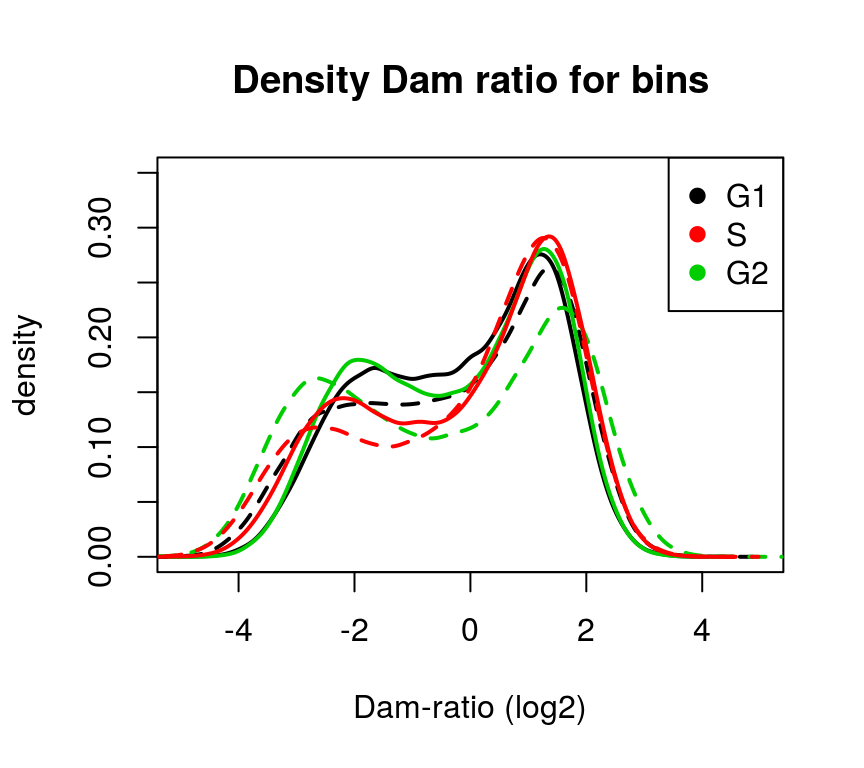

```r
# Plot the distributions for the various samples
plot(1, 1, type = "n", xlim = c(-5, 5), ylim = c(0, 0.35),
     xlab = "Dam-ratio (log2)", ylab = "density", main = "Density Dam ratio for bins")

for (i in 1:n) {
  lines(density(mcols(bins.norm)[, i]),
        col = as.numeric(samples.df$phase)[i], lwd = 2,
        lty = as.numeric(samples.df$replicate)[i])
}

legend("topright", legend = levels(samples.df$phase), pch = 19,
       col = 1:length(levels(samples.df$phase)))
```

We make the assumption that the distributions are the same between time points, and thus scale the data.

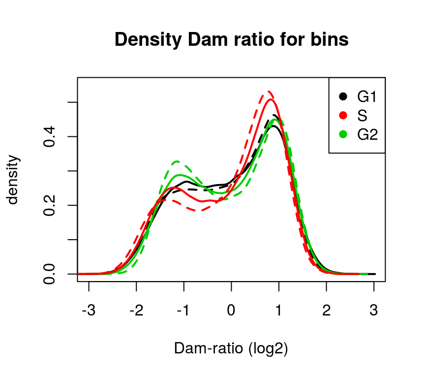

```r
bins.norm.scaled <- bins.norm
mcols(bins.norm.scaled) <- scale(as(mcols(bins.norm.scaled), "data.frame"))

# Plot the distributions for the various samples after scaling
plot(1, 1, type = "n", xlim = c(-3, 3), ylim = c(0, 0.55),
     xlab = "Dam-ratio (log2)", ylab = "density", main = "Density Dam ratio for bins")

for (i in 1:n) {
  lines(density(mcols(bins.norm.scaled)[, i]),
        col = as.numeric(samples.df$phase)[i], lwd = 2,
        lty = as.numeric(samples.df$replicate)[i])
}

legend("topright", legend = levels(samples.df$phase), pch = 19,
       col = 1:length(levels(samples.df$phase)))
```

[Note how the distributions are not necessarily identical.]

### 5) Define LAD scores

LAD scores are a bit different. I made the assumption that overall the binned distribution does not change. In other words, every condition has the same amount of lamina and therefore the same total DNA that can sit there. LADs are basically combined bins that form domains. They can correspond to a few bins, but also to dozens of them. As they are not corresponding to constant genomic sizes, you cannot easily scale them or anything. Instead, I decided to define the LAD score as the mean of the corresponding normalized & scaled bins.

```r
# Get the lamina counts
LADs.counts.lamina <- LADs.counts
mcols(LADs.counts.lamina) <- mcols(LADs.counts)[, seq(1, 2*n, 2)]

# Duplicate LADs for normalized scores
LADs.norm <- LADs

ovl <- findOverlaps(LADs.norm, bins.norm.scaled)

# Calculate the mean score per region and add this as column
mcols(LADs.norm) <- do.call(rbind, tapply(subjectHits(ovl),
                                          queryHits(ovl),
                                          function(x) colMeans(as(mcols(bins.norm.scaled), "data.frame")[x, ],
                                                               na.rm = T),
                                          simplify = TRUE))

saveRDS(LADs.norm, file.path(output_dir, "LADs_norm.rds"))
```

### 6) Voom modeling

- bin length / number of (mappable) GATC fragments. bin length means more data points and thus better estimated variance.
- Accessibility. Accessibility means more reads per data point and thus better estimated variance.
- Lamina association. Lamina associated DNA is usually compact (not accessible), but at the same time you have more target reads. This most likely means a better estimated variance.

This means that I have to make a decision which factor to use to estimate the variance curve. Easiest is probably the total number of reads (Dam + Dam-lamin).

```r
# Model variance for each bin, based on various parameters
design <- model.matrix(~ 0 + samples.df$phase + samples.df$replicate)

# # 1) Combined (normalized) counts
# bins.voom <- voom_damid(bins.counts.norm.combined, bins.norm.scaled)
#
# # 2) Lamina counts
# bins.voom <- voom_damid(bins.counts.lamina, bins.norm.scaled)
#
# # 3) Dam counts
# bins.voom <- voom_damid(bins.counts.dam, bins.norm.scaled)
#
# # 4) Combined counts
# bins.voom <- voom_damid(bins.counts.combined, bins.norm.scaled)
#
# # 5) Lamina counts - with design
# bins.voom <- voom_damid(bins.counts.lamina, bins.norm.scaled, design = NULL)
#
# # 6) Lamina scores - with design
# tmp <- bins.norm.scaled
# mcols(tmp) <- 2^as(mcols(bins.norm.scaled), "data.frame")
# LADs.voom <- voom_damid(tmp, bins.norm.scaled, design = NULL)
#
#
# 1b) LADs - lamina counts
LADs.voom <- voom_damid(LADs.counts.lamina, LADs.norm, design = NULL)
```

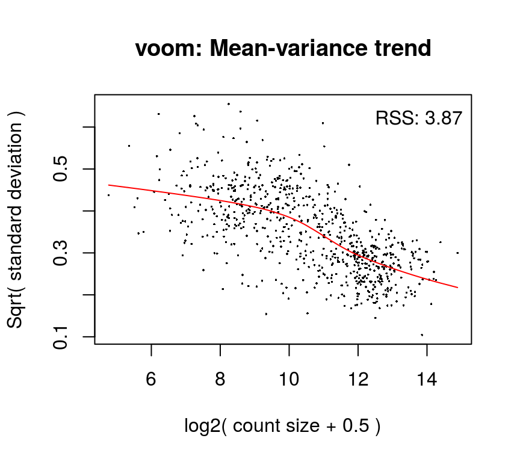

```r
# 2b) LADs - lamina scores
tmp <- LADs.norm
mcols(tmp) <- 2^as(mcols(LADs.norm), "data.frame")
LADs.voom <- voom_damid(tmp, LADs.norm, design = NULL)
```

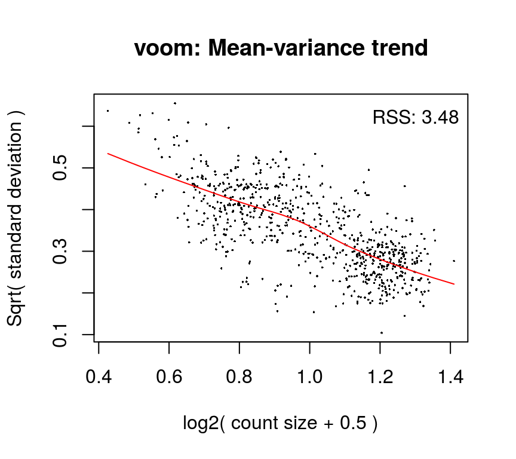

For now, I will indeed continue with the lamina counts.

```r
# Lamina counts
# bins.voom <- voom_damid(bins.counts.lamina, bins.norm.scaled,
#                         design = NULL, plot = FALSE)
LADs.voom <- voom_damid(LADs.counts.lamina, LADs.norm, design = NULL,
                        plot = F)
```

Note: another thing to consider is the design matrix used in the variance modeling. For now, I did not use a design matrix, which means that all measurements are used for the standard deviation. In case of a supplied matrix, the modeling will be done taking that into account.

### 7) Differential LADs with limma

Let’s continue with the differential bin calling using limma and the voom modelled variance weights.

```r
# Make experimental desigin
design <- model.matrix(~ 0 + samples.df$phase)
colnames(design) <- levels(samples.df$phase)

# Run limma using a two-state model
fit <- lmFit(LADs.voom, design)
cont.matrix <- makeContrasts(G2 - G1, levels = design)
fit <- contrasts.fit(fit, cont.matrix)
fit <- eBayes(fit)
topTable(fit)
```

```
##          logFC      AveExpr         t      P.Value    adj.P.Val        B
## 2   -0.7945113  0.089960118 -8.364938 2.724488e-07 0.0002048815 7.170842
## 283 -0.6339853  0.055405565 -7.258075 1.728300e-06 0.0004077416 5.365216
## 554 -0.4439008  0.492779558 -7.321738 1.547332e-06 0.0004077416 5.361756
## 119 -0.7979839  0.006765439 -6.988844 2.775760e-06 0.0004077416 4.879943
## 552 -0.8021065 -0.164139838 -6.931737 3.073088e-06 0.0004077416 4.713571
## 376 -0.5099466  0.362591754 -6.899871 3.253258e-06 0.0004077416 4.656270
## 121 -0.8209717 -0.118273943 -6.278612 1.015682e-05 0.0008226873 3.629513
## 311  0.3545880  0.783559760  6.296272 9.826224e-06 0.0008226873 3.596397
## 240  0.2737618  0.959573137  6.341679 9.026507e-06 0.0008226873 3.506733
## 635 -0.6642958  0.045958884 -6.186016 1.208966e-05 0.0008226873 3.489696
```

```r
# Alternatively, run limma using splines
# Good in theory, but I don't understand it properly yet
# Let's use one with 1 df (basic linear model)
# library(splines)
# X <- ns(as.numeric(samples.df$phase), df = 1)
# # Then fit separate curves for the control and treatment groups:
# design <- model.matrix(~ X)
# fit <- lmFit(LADs.voom, design)
# fit <- eBayes(fit)
# topTable(fit)

# Get the results
results <- decideTests(fit, adjust.method = "BH", p.value = 0.05, method = "global")

saveRDS(fit, file.path(output_dir, "LADs_fit.rds"))
saveRDS(results, file.path(output_dir, "LADs_results.rds"))

results <- results[, 1]
```

```r
# Get the indices
idx <- which(results != 0)
idx.up <- which(results > 0)
idx.down <- which(results < 0)

# And return the values
cat("Given, p-value = 0.05")
```

```
## Given, p-value = 0.05
```

```r
cat("   bins up:", length(idx.up))
```

```
##    bins up: 71
```

```r
cat("   bins down:", length(idx.down))
```

```
##    bins down: 65
```

```r
# Save .bed files
export.bed(LADs[idx.up], file.path(output_dir, "LADs_up.bed"))
export.bed(LADs[idx.down], file.path(output_dir, "LADs_down.bed"))
```

#### Visualize results

Now, I will try to visualize the results in a useful plot.

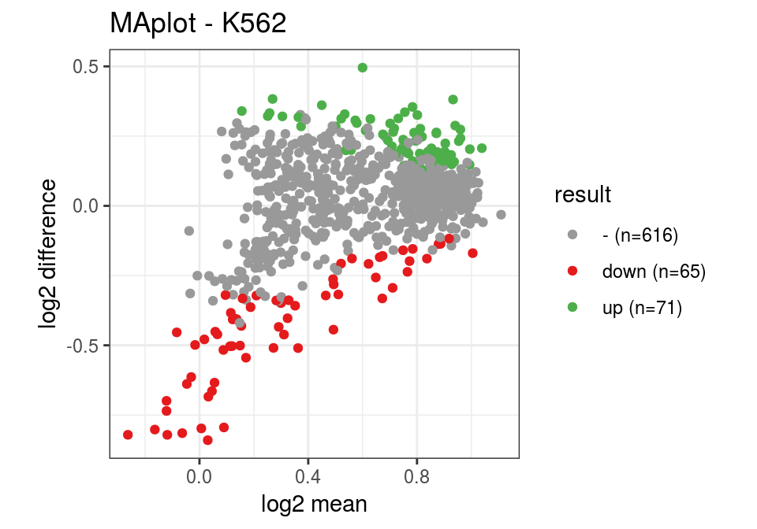

```r
# limma MA-plot
# plotMD(fit, status = results)
df <- data.frame(x = fit$Amean,
                 y = fit$coefficients[, 1],
                 result = factor(results, levels = c("0", "-1", "1")))

ggplot(df, aes(x = x, y = y, col = result)) +
  geom_point(alpha = 1) +
  ggtitle(paste0("MAplot - ", cell)) +
  xlab("log2 mean") +
  ylab("log2 difference") +
  scale_color_manual(values = brewer.pal(9, "Set1")[c(9, 1, 3)],
                     labels = paste0(c("-", "down", "up"),
                                     " (n=",
                                     as.vector(table(df$result)),
                                     ")")) +
  theme_bw() +
  theme(aspect.ratio = 1)
```

### 8) Save results

For later comparisons, I will save the results.

```r
# Save files as RDS
saveRDS(bins, file.path(output_dir, "bins_filtered.rds"))
saveRDS(bins.norm, file.path(output_dir, "bins_norm.rds"))
saveRDS(fit, file.path(output_dir, "bins_limma.rds"))
saveRDS(results, file.path(output_dir, "results_limma.rds"))
```

### 9) How does this compare with cLADs?

Looking at the data, it seems that the regions that lose the lamina interactions are depleted in cLADs. Can I verify this?

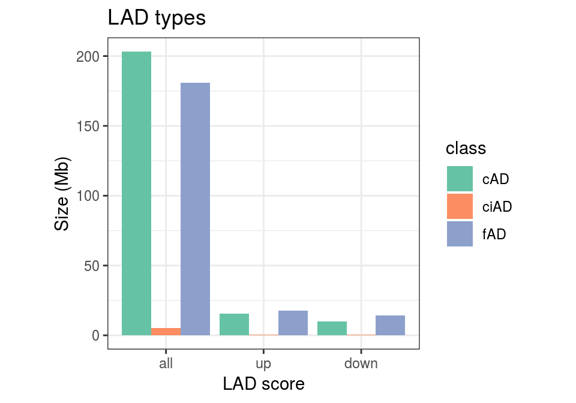

```r
cLADs <- readRDS("/DATA/usr/t.v.schaik/proj/3D_nucleus/results/ts180130_laminaVsNucleolus/ts180131_differential_localization/DamID_cLADs.rds")

ovl <- overlapsAny(cLADs, LADs)
ovl.up <- overlapsAny(cLADs, LADs[idx.up])
ovl.down <- overlapsAny(cLADs, LADs[idx.down])

df <- data.frame(class = c("cAD", "ciAD", "fAD"),
                 all = as.vector(table(cLADs$calls[ovl])),
                 up = as.vector(table(cLADs$calls[ovl.up])),
                 down = as.vector(table(cLADs$calls[ovl.down])))
df.melt <- melt(df, id.vars = "class")

# Absolute scores
ggplot(df.melt, aes(x = variable, y = value / 50, fill = class)) +
  geom_bar(stat = "identity", position = "dodge") +
  ggtitle("LAD types") +
  xlab("LAD score") +
  ylab("Size (Mb)") +
  scale_fill_brewer(palette = "Set2") +
  theme_bw() +
  theme(aspect.ratio = 1)
```

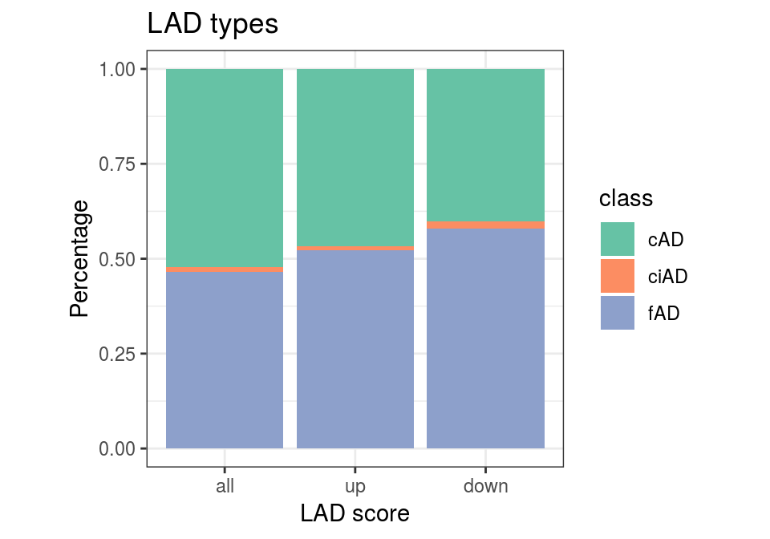

```r
# Fractions
df[, 2:4] <- t(t(df[, 2:4]) / colSums(df[, 2:4]))
df.melt <- melt(df, id.vars = "class")

ggplot(df.melt, aes(x = variable, y = value, fill = class)) +
  geom_bar(stat = "identity") +
  ggtitle("LAD types") +
  xlab("LAD score") +
  ylab("Percentage") +
  scale_fill_brewer(palette = "Set2") +
  theme_bw() +
  theme(aspect.ratio = 1)
```

Yes. Not a very extreme enrichment though.

### 10) Where are the differential regions on the chromosome?

Looking at the data, it seems that the regions that lose the lamina interactions are mostly located at the ends of chromosomes. Can I verify this?

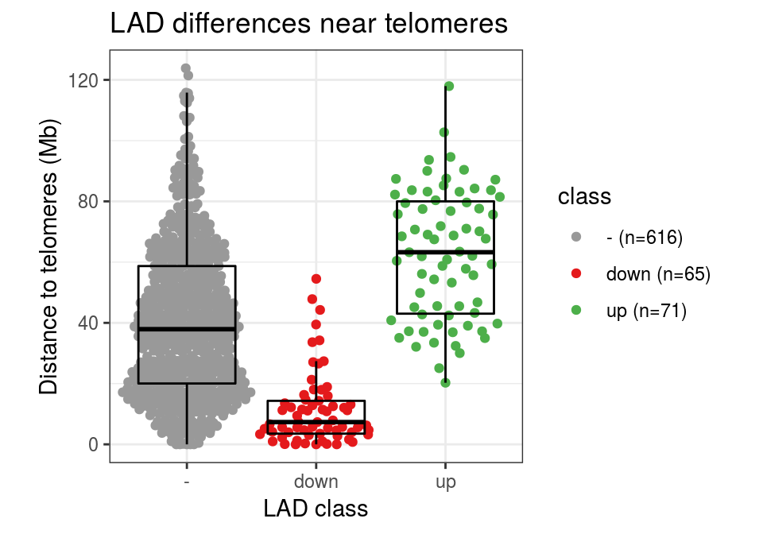

```r
# Define telomeres
telomeres <- GRanges(seqnames = rep(seqlevels(LADs), times = 2),
                     ranges = IRanges(start = c(rep(1, length(seqlevels(LADs))),
                                                seqlengths(LADs)),
                                      end = c(rep(1, length(seqlevels(LADs))),
                                              seqlengths(LADs))))

# Distance to telomeres data frame
LADs$distance_to_telomeres <- mcols(distanceToNearest(LADs, telomeres))$distance

df <- data.frame(class = factor("-", levels = c("-", "down", "up")),
                 distance_to_telomeres = LADs$distance_to_telomeres)
df$class[idx.down] <- "down"
df$class[idx.up] <- "up"

# Plot
ggplot(df, aes(x = class, y = distance_to_telomeres / 1e6, col = class)) +
  geom_quasirandom(width = 0.5) +
  geom_boxplot(outlier.shape = NA, fill = NA, col = "black") +
  ggtitle("LAD differences near telomeres") +
  xlab("LAD class") +
  ylab("Distance to telomeres (Mb)") +
  scale_color_manual(values = brewer.pal(9, "Set1")[c(9, 1, 3)],
                     labels = paste0(c("-", "down", "up"),
                                     " (n=",
                                     as.vector(table(df$class)),
                                     ")")) +
  theme_bw() +
  theme(aspect.ratio = 1)
```

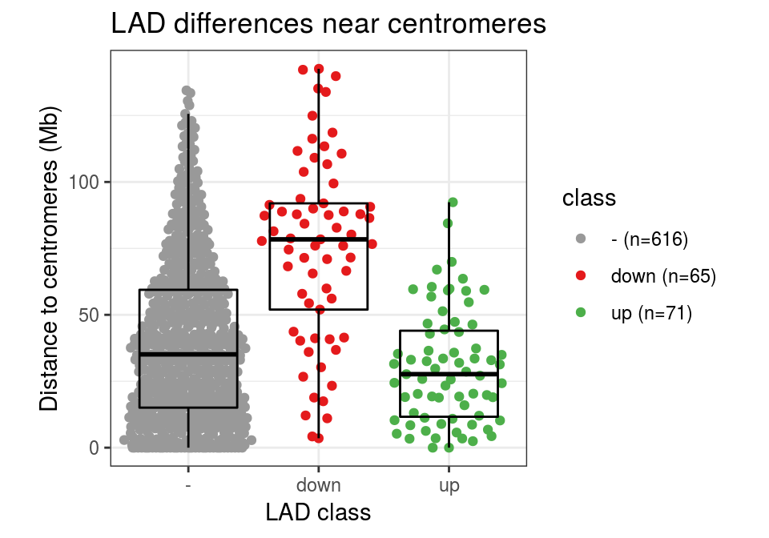

```r
# Distance to telomeres data frame
LADs$distance_to_centromeres <- mcols(distanceToNearest(LADs, centromeres))$distance

df$distance_to_centromeres = LADs$distance_to_centromeres

# Plot
ggplot(df, aes(x = class, y = distance_to_centromeres / 1e6, col = class)) +
  geom_quasirandom(width = 0.5) +
  geom_boxplot(outlier.shape = NA, fill = NA, col = "black") +
  ggtitle("LAD differences near centromeres") +
  xlab("LAD class") +
  ylab("Distance to centromeres (Mb)") +
  scale_color_manual(values = brewer.pal(9, "Set1")[c(9, 1, 3)],
                     labels = paste0(c("-", "down", "up"),
                                     " (n=",
                                     as.vector(table(df$class)),
                                     ")")) +
  theme_bw() +
  theme(aspect.ratio = 1)
```

Yes, definitely. Why? Some outliers though. Again, why?

Telomeres form a disc in G2: https://doi.org/10.1002/cyto.a.20159

### 11) Unnormalized scores

I want to highlight that these differential genes are not simply Dam-only related. To do so, I will here plot the library size-normalized values for lamina and Dam-only.

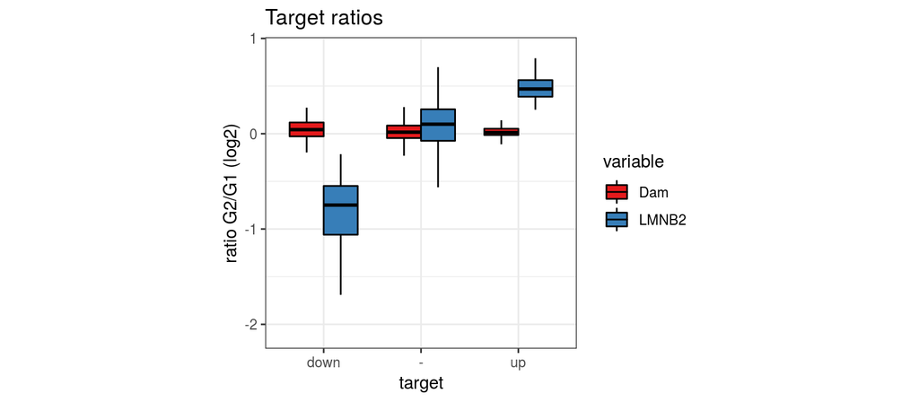

```r
# Get the library size normalized values
df <- as(mcols(LADs.counts.norm), "data.frame")

df.names <- expand.grid(c("_LMNB2", "_Dam"), samples.df$phase)
names(df) <- paste0(df.names$Var2, df.names$Var1)

# Add result
df$result <- "-"
df$result[results == 1] <- "up"
df$result[results == -1] <- "down"
df$result <- factor(df$result, levels = c("down", "-", "up"))

# Plot
df.new <- data.frame(result = df$result,
                     Dam = log2((rowMeans(df[, grep("G2_Dam", names(df))],
                                    na.rm = T) + 1) /
                       (rowMeans(df[, grep("G1_Dam", names(df))],
                                na.rm = T) + 1)),
                     LMNB2 = log2((rowMeans(df[, grep("G2_LMNB2", names(df))],
                                    na.rm = T) + 1) /
                       (rowMeans(df[, grep("G1_LMNB2", names(df))],
                                na.rm = T) + 1)))

df.new <- melt(df.new, id.vars = "result")

ggplot(df.new, aes(x = result, y = value, fill = variable)) +
  # geom_quasirandom() +
  geom_boxplot(outlier.shape = NA, col = "black", width = 0.7, position = "dodge") +
  ggtitle("Target ratios") +
  xlab("target") +
  ylab("ratio G2/G1 (log2)") +
  scale_fill_brewer(palette = "Set1") +
  theme_bw() +
  theme(aspect.ratio = 1)
```

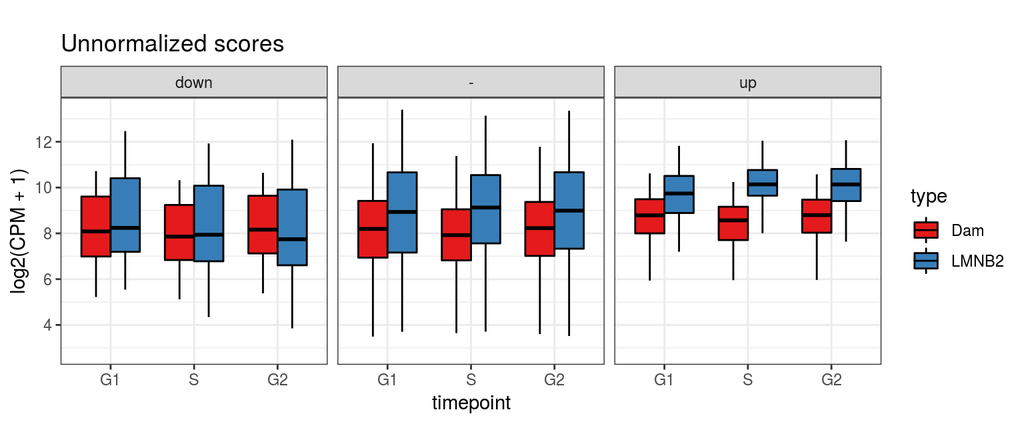

```r
df <- melt(df, id.vars = "result")
df$phase <- factor(gsub("_(D|L).*", "", df$variable),
                   levels = levels(samples.df$phase))
df$type <- factor(gsub(".*_", "", df$variable))

ggplot(df, aes(x = phase, y = log2(value + 1), col = phase, fill = type)) +
  # geom_quasirandom() +
  geom_boxplot(outlier.shape = NA, col = "black", width = 0.7, position = "dodge") +
  ggtitle("Unnormalized scores") +
  xlab("timepoint") +
  ylab("log2(CPM + 1)") +
  facet_grid(. ~ result) +
  scale_fill_brewer(palette = "Set1") +
  theme_bw() +
  theme(aspect.ratio = 1)
```

### 12) Differences within one LAD

```r
library(caTools)
```

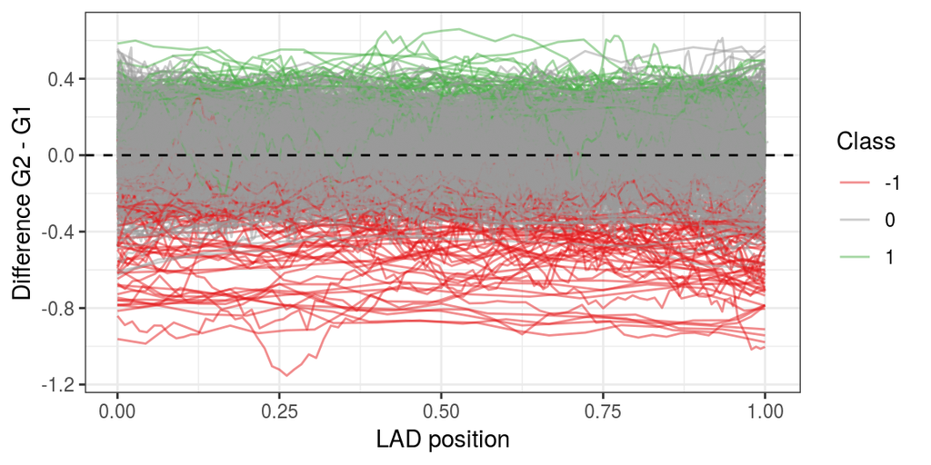

```r
# To create the figure, I should get all the values overlapping LADs and scale
# their "distance" from 0 to 1. For simplicity and because of relatively low
# LAD numbers, let's loop over them.

# First, create bins with mean score per class
bins.norm.scaled.mean <- bins.norm.scaled
mcols(bins.norm.scaled.mean) <- do.call(cbind,
                                        tapply(samples.df$name,
                                               samples.df$phase,
                                               function(x) rowMeans(as(mcols(bins.norm.scaled), "data.frame")[, x],
                                                                    na.rm = T)))

# Initially output data frame
df <- c()

# Overlap LADs and bins
ovl <- findOverlaps(LADs, bins)

# Loop over LADs
for (i in 1:length(LADs)) {

  # Get LAD and bins
  LAD.i <- LADs[i]
  bins.i <- bins.norm.scaled.mean[subjectHits(ovl)[queryHits(ovl) == i]]

  # Create a new data frame of bin values, with distance normalized
  # Distance: first bin=0 and last bin=1
  df.i <- data.frame(position = (start(bins.i) - start(LAD.i)) / (width(LAD.i) - width(bins.i)[1]),
                     diff = bins.i$G2 - bins.i$G1,
                     LAD = i,
                     class = results[i])
  df.i <- cbind(df.i,
                as(mcols(bins.i), "data.frame"))

  # Let's only take reasonably sized LADs: 15 bins
  # if (length(bins.i) <= 15) {
  #   next
  # }

  df.i$diff.smooth <- runmean(df.i$diff,
                              k = 9, endrule = "mean")

  # Add to final df
  df <- rbind(df, df.i)

}

# Plot diff for every LAD
plt <- ggplot(df, aes(x = position, y = diff.smooth, group = LAD, col = factor(class))) +
  geom_line(alpha = 0.5) +
  geom_hline(yintercept = 0, col = "black", linetype = "dashed") +
  xlab("LAD position") +
  ylab("Difference G2 - G1") +
  scale_color_manual(values = brewer.pal(9, "Set1")[c(1, 9, 3)],
                     name = "Class") +
  theme_bw()

plot(plt)
```

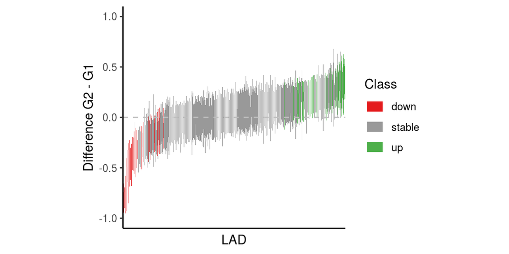

```r
# Boxplots for every LAD, sorted by median difference
LAD.diff <- tapply(df$diff, df$LAD, mean)
idx <- order(LAD.diff)
df$LAD <- factor(df$LAD, levels = as.character(idx))

ggplot(df, aes(x = LAD, y = diff, fill = factor(class))) +
  geom_boxplot(col = NA, outlier.shape = NA, coef = 0) +
  geom_hline(yintercept = 0, col = "grey", linetype = "dashed") +
  scale_fill_manual(values = brewer.pal(9, "Set1")[c(1, 9, 3)],
                    name = "Class",
                    labels = c("down", "stable", "up")) +
  xlab("LAD") +
  ylab("Difference G2 - G1") +
  coord_cartesian(ylim = c(-1.0, 1.0)) +
  theme_classic() +
  theme(aspect.ratio = 1,
        axis.text.x=element_blank(),
        axis.ticks.x=element_blank())
```

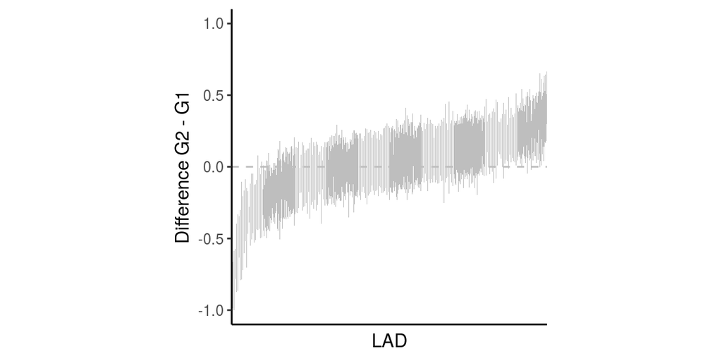

```r
ggplot(df, aes(x = LAD, y = diff)) +
  geom_boxplot(col = NA, outlier.shape = NA, coef = 0, fill = "grey") +
  geom_hline(yintercept = 0, col = "grey", linetype = "dashed") +
  xlab("LAD") +
  ylab("Difference G2 - G1") +
  coord_cartesian(ylim = c(-1.0, 1.0)) +
  theme_classic() +
  theme(aspect.ratio = 1,
        axis.text.x=element_blank(),
        axis.ticks.x=element_blank())
```

### Conclusion

This seems like a statistically sound method to call differential bins. I think the procedure will be much cleaner with replicates.

Next: these differential bins in pA-DamID, do they also show a difference in the old DamID? (Remember: the pA-DamID does not show differences of the old differential bins.)